# US Data EDA

Jaclyn Coate & Josh Eysenbach

2020-07-23

# US COVID Data

## EDA

### US Covid Data

We leveraged the [The Covid Tracking Project](https://covidtracking.com/) for analyzing the COVID impact on the United States. The COVID Tracking Project is being utilized by many leading and trusted groups such as the CDC, HHS, and Johns Hopkins.

Using the simple read.csv command we load the data from our Data folder for our [Term Project](https://github.com/JaclynCoate/6373_Time_Series/tree/master/TermProject) Github repository.

```r
us <- read.csv("https://raw.githubusercontent.com/JaclynCoate/6373_Time_Series/master/TermProject/Data/USdaily7.19.csv", header = T, strip.white = T)
str(us)
```

```
## 'data.frame':    179 obs. of  25 variables:
##  $ date                    : int  20200718 20200717 20200716 20200715 20200714 20200713 20200712 20200711 20200710 20200709 ...
##  $ states                  : int  56 56 56 56 56 56 56 56 56 56 ...
##  $ positive                : int  3692061 3626881 3549648 3478695 3413313 3350434 3291969 3230991 3167984 3101339 ...
##  $ negative                : int  41273443 40576852 39802297 39048662 38351244 37653841 36990207 36323867 35751437 34994707 ...
##  $ pending                 : int  3032 3002 2929 2947 960 2610 2639 2618 2493 2530 ...
##  $ hospitalizedCurrently   : int  57562 57705 57369 56143 55533 53988 52632 51834 51577 43924 ...
##  $ hospitalizedCumulative  : int  276439 274436 271758 269543 267127 264865 263651 262712 257571 255253 ...
##  $ inIcuCurrently          : int  6396 6453 6359 6317 6235 6074 5930 5939 5896 5845 ...
##  $ inIcuCumulative         : int  12342 12243 12091 12002 11857 11749 11679 11612 11523 11370 ...
##  $ onVentilatorCurrently   : int  2343 2353 2317 2317 2263 2259 2182 2169 2197 2127 ...
##  $ onVentilatorCumulative  : int  1211 1200 1175 1166 1154 1142 1136 1128 1118 1138 ...
##  $ recovered               : int  1122720 1106844 1090645 1075882 1049098 1031939 1006326 995576 983185 969111 ...
##  $ dateChecked             : Factor w/ 179 levels "2020-01-22T00:00:00Z",..: 179 178 177 176 175 174 173 172 171 170 ...
##  $ death                   : int  132395 131523 130572 129598 128740 128004 127677 127201 126444 125590 ...
##  $ hospitalized            : int  276439 274436 271758 269543 267127 264865 263651 262712 257571 255253 ...
##  $ lastModified            : Factor w/ 179 levels "2020-01-22T00:00:00Z",..: 179 178 177 176 175 174 173 172 171 170 ...
##  $ total                   : int  44968536 44206735 43354874 42530304 41765517 41006885 40284815 39557476 38921914 38098576 ...
##  $ totalTestResults        : int  44965504 44203733 43351945 42527357 41764557 41004275 40282176 39554858 38919421 38096046 ...
##  $ posNeg                  : int  44965504 44203733 43351945 42527357 41764557 41004275 40282176 39554858 38919421 38096046 ...
##  $ deathIncrease           : int  872 951 974 858 736 327 476 757 854 867 ...
##  $ hospitalizedIncrease    : int  2003 2678 2215 2416 2262 1214 939 5141 2318 1719 ...
##  $ negativeIncrease        : int  696591 774555 753635 697418 697403 663634 666340 572430 756730 639952 ...
##  $ positiveIncrease        : int  65180 77233 70953 65382 62879 58465 60978 63007 66645 58836 ...
##  $ totalTestResultsIncrease: int  761771 851788 824588 762800 760282 722099 727318 635437 823375 698788 ...
##  $ hash                    : Factor w/ 179 levels "0063e380f01c09a74ff18ab1940b36390ef365d9",..: 118 30 96 170 111 66 61 116 131 5 ...
```

### US: Available Variables

1. *date* - Date on which data was compiled by The COVID Tracking Project.
2. *states* - Number of states and territories included in the US dataset for this day.
3. *positive* - Total number of people with confirmed OR probable COVID-19 reported by the state or territory (per the expanded CSTE case definition of April 5th, 2020 approved by the CDC). A confirmed case is a person who has a positive test result from an FDA approved diagnostic molecular test. A probable case is a person who either has presentable symptoms WITH epidemiological evidence or has BOTH a positive presumptive laboratory test AND also EITHER presentable symptoms OR epidemiological evidence. Epidemiological evidence refers either to close-proximity contact with a known case or travel history to an area with high disease incidence. According to the guidelines, FDA approved antibody and antigen tests are considered part of presumptive laboratory evidence.
4. *negative* - Individuals with a completed viral test that returned a negative result. For states / territories that do not report this number directly, we compute it using one of several methods, depending on which data points the state provides.
5. *pending* - Total number of viral tests that have not been completed as reported by the state or territory.
6. *hospitalizedCurrently* - Individuals who are currently hospitalized with COVID-19. Definitions vary by state / territory. Where possible, we report hospitalizations with confirmed or probable COVID-19 cases per the expanded CSTE case definition of April 5th, 2020 approved by the CDC.
7. *hospitalizedCumulative* - Total number of individuals who have ever been hospitalized with COVID-19. Definitions vary by state / territory. Where possible, we report hospitalizations with confirmed or probable COVID-19 cases per the expanded CSTE case definition of April 5th, 2020 approved by the CDC.
8. *inIcuCurrently* - Individuals who are currently hospitalized in the Intensive Care Unit with COVID-19. Definitions vary by state / territory. Where possible, we report patients in the ICU with confirmed or probable COVID-19 cases per the expanded CSTE case definition of April 5th, 2020 approved by the CDC.
9. *inIcuCumulative* - Total number of individuals who have ever been hospitalized in the Intensive Care Unit with COVID-19. Definitions vary by state / territory. Where possible, we report patients in the ICU with confirmed or probable COVID-19 cases per the expanded CSTE case definition of April 5th, 2020 approved by the CDC.
10. *onVentilatorCurrently* - Individuals who are currently hospitalized under advanced ventilation with COVID-19. Definitions vary by state / territory. Where possible, we report patients on ventilation with confirmed or probable COVID-19 cases per the expanded CSTE case definition of April 5th, 2020 approved by the CDC.
11. *onVentilatorCumulative* - Total number of individuals who have ever been hospitalized under advanced ventilation with COVID-19. Definitions vary by state / territory. Where possible, we report patients on ventilation with confirmed or probable COVID-19 cases per the expanded CSTE case definition of April 5th, 2020 approved by the CDC.
12. *recovered* - Total number of people that are identified as recovered from COVID-19. States provide disparate definitions on what constitutes as a “recovered” COVID-19 case. Types of “recovered” cases include those who are discharged from hospitals, released from isolation after meeting CDC guidance on symptoms cessation, or those who have not been identified as fatalities after a number of days (30 or more) post disease onset. Specifics vary for each state or territory.
13. *dateChecked* - Deprecated. This is an old label for *lastUpdateEt*.
14. *death* - Total fatalities with confirmed OR probable COVID-19 case diagnosis (per the expanded CSTE case definition of April 5th, 2020 approved by the CDC). In states where the information is available, it only tracks fatalities with confirmed OR probable COVID-19 case diagnosis where COVID-19 is an underlying cause of death according to the death certificate based on WHO guidelines.
15. *hospitalized* - Deprecated. Old label for hospitalizedCumulative.
16. *lastModified* - Deprecated. Old label for lastUpdateET.
17. *total* - Deprecated. Computed by adding *positive*, *negative*, and *pending* values.
18. *totalTestRestuls* - Currently computed by adding positive and negative values to work around reporting lags between positives and total tests and because some states do not report totals. Deprecated in the API and soon to be replaced on the website as well.
19. *posNeg* - Deprecated. Computed by adding *positive* and *negative* values.
20. *deathIncrease* - Increase in *death* computed by subtracting the value of *death* for the previous day from the value of *death* for the current day.
21. *hospitalizedIncrease* - Increase in *hospitalizedCumulative* computed by subtracting the value of *hospitalizedCumulative* for the previous day from the value of *hospitalizedCumulative* for the current day.
22. *negativeIncrease* - Increase in *negative* computed by subtracting the value of *negative* for the previous day from the value for *negative* from the current day.
23. *positiveIncrease* - Increase in *positive* computed by subtracting the value of *positive* from the previous day from the value of *positive* for the current day.
24. *totalTestRestulsIncrease* - Deprecated. Increase in *totalTestResults* computed by subtracting the value of *totalTestResults* for the previous day from the value of *totalTestResults* for the current day.
25. *hash* - A hash for this record

### Variable Evaluation and Formatting

```r
us <- transform(us, date = as.Date(as.character(date), "%Y%m%d"))
head(us)
```

```
##         date states positive negative pending hospitalizedCurrently
## 1 2020-07-18     56  3692061 41273443    3032                 57562
## 2 2020-07-17     56  3626881 40576852    3002                 57705
## 3 2020-07-16     56  3549648 39802297    2929                 57369
## 4 2020-07-15     56  3478695 39048662    2947                 56143
## 5 2020-07-14     56  3413313 38351244     960                 55533
## 6 2020-07-13     56  3350434 37653841    2610                 53988
##   hospitalizedCumulative inIcuCurrently inIcuCumulative
## 1                 276439           6396           12342
## 2                 274436           6453           12243
## 3                 271758           6359           12091
## 4                 269543           6317           12002
## 5                 267127           6235           11857
## 6                 264865           6074           11749
##   onVentilatorCurrently onVentilatorCumulative recovered
```

[output cut: 34 more lines]

### Logical Variable Removal

During this project we will be trying to surface those metrics that properly evaluate the severity of COVID in the US. In order to simplify our data set we will remove all variables that do not directly link to metrics dealing with COVID or variables that are depcitign the same information. E.g. *totalTestResults* and *postNeg*.

```r
us <- subset(us, select = -c(states, dateChecked, hospitalized, lastModified, total, posNeg, totalTestResultsIncrease, hash))
head(us)
```

```
##         date positive negative pending hospitalizedCurrently
## 1 2020-07-18  3692061 41273443    3032                 57562
## 2 2020-07-17  3626881 40576852    3002                 57705
## 3 2020-07-16  3549648 39802297    2929                 57369
## 4 2020-07-15  3478695 39048662    2947                 56143
## 5 2020-07-14  3413313 38351244     960                 55533
## 6 2020-07-13  3350434 37653841    2610                 53988
##   hospitalizedCumulative inIcuCurrently inIcuCumulative
## 1                 276439           6396           12342
## 2                 274436           6453           12243
## 3                 271758           6359           12091
## 4                 269543           6317           12002
## 5                 267127           6235           11857
## 6                 264865           6074           11749
##   onVentilatorCurrently onVentilatorCumulative recovered  death
```

[output cut: 20 more lines]

### NA Evaluation

Upon evaluating the columns that contain not available information, we can see in the early dates of data collection the US had a low count of COVID cases. Since it is likely that those metrics were actually zero since they weren’t even being collected at that time, we will repalce all NAs with zeros.

```r
us[is.na(us)] <- 0
tail(us)
```

```
##           date positive negative pending hospitalizedCurrently
## 174 2020-01-27        2        0       0                     0
## 175 2020-01-26        2        0       0                     0
## 176 2020-01-25        2        0       0                     0
## 177 2020-01-24        2        0       0                     0
## 178 2020-01-23        2        0       0                     0
## 179 2020-01-22        2        0       0                     0
##     hospitalizedCumulative inIcuCurrently inIcuCumulative
## 174                      0              0               0
## 175                      0              0               0
## 176                      0              0               0
## 177                      0              0               0
## 178                      0              0               0
## 179                      0              0               0
##     onVentilatorCurrently onVentilatorCumulative recovered death
```

[output cut: 20 more lines]

### Zero variance variable check

All variables show a variance therefore we will keep all in the model for now

```r
skim(us)
```

```
## Skim summary statistics
##  n obs: 179
##  n variables: 17
##
## ── Variable type:Date ─────────────────────────────────────────────────────────────────────────────────────────────────────────────────────
##  variable missing complete   n        min        max     median n_unique
##      date       0      179 179 2020-01-22 2020-07-18 2020-04-20      179
##
## ── Variable type:integer ──────────────────────────────────────────────────────────────────────────────────────────────────────────────────
##              variable missing complete   n          mean            sd
##         deathIncrease       0      179 179     739.64        736.87
##  hospitalizedIncrease       0      179 179    1544.35       1972.24
##              negative       0      179 179 9542260.32          1.2e+07
##      negativeIncrease       0      179 179  230577.89     228080.46
##              positive       0      179 179   1e+06       1080318.9
##      positiveIncrease       0      179 179   20626.03      18316.97
##      totalTestResults       0      179 179       1.1e+07       1.3e+07
##     p0    p25     p50           p75          p100     hist
##      0    3.5     655    1216          2740       ▇▂▃▂▁▂▁▁
##  -2841    0      1245    2258.5       17320       ▁▇▂▁▁▁▁▁
##      0 2578   3269209       1.7e+07       4.1e+07 ▇▂▁▁▁▁▁▁
##     -3  626    136639  414259.5      774555       ▇▂▂▂▂▁▂▁
##      2 1161    786933 1866669.5     3692061       ▇▂▂▂▂▁▁▁
##      0  203.5   21590   28924.5       77233       ▇▂▇▂▁▁▁▁
##      2 3739   4056142       1.9e+07       4.5e+07 ▇▂▁▁▁▁▁▁
##
## ── Variable type:numeric ──────────────────────────────────────────────────────────────────────────────────────────────────────────────────
##                variable missing complete   n      mean        sd p0   p25
##                   death       0      179 179  50519.59  49837.79  0  26.5
##  hospitalizedCumulative       0      179 179 107636.91  1e+05     0   6
##   hospitalizedCurrently       0      179 179  26293.04  21887.94  0   0
##         inIcuCumulative       0      179 179   4237.38   4434.51  0   0
##          inIcuCurrently       0      179 179   5476.62   5033.25  0   0
##  onVentilatorCumulative       0      179 179    384.97    405.83  0   0
##   onVentilatorCurrently       0      179 179   2346.8    2259.85  0   0
##                 pending       0      179 179   6483.64  14080.45  0 330
##               recovered       0      179 179 271316.65 343207.89  0   0
##    p50      p75    p100     hist
##  39028  1e+05    132395 ▇▁▁▁▁▂▂▂
##  97369 215272    276439 ▇▁▁▁▂▁▃▂
##  30890  44527     59538 ▇▁▁▂▃▃▂▃
##   2193   8737.5   12342 ▇▂▁▁▂▂▂▂
##   5597   9069     15130 ▇▁▃▃▂▂▂▂
##    214    720      1211 ▇▂▁▁▂▂▁▂
##   2172   4501.5    7070 ▇▁▃▁▂▂▂▁
##   2186   3576     65709 ▇▁▁▁▁▁▁▁
##  69493 563494.5 1122720 ▇▂▁▁▁▁▁▁
```

## COVID Case Cumulative Variable Review

Below we will use a basic lines graph by day to see the general trend of some of the basic cumulative variables that are provided by our raw data set. The cumulative variables are interesting to see the general trend of the data. However, these would not be beneficial from a forecasting iniative due to the fact that these will just continue to trend upwards as the virus spreads. It gives no real insight that could be used for our COVID relief efforts for hospitals.

### Cumulative COVID Cases in US

We can see that the total cumulative COVID cases are increasing overtime with what appears to be no reprieve.

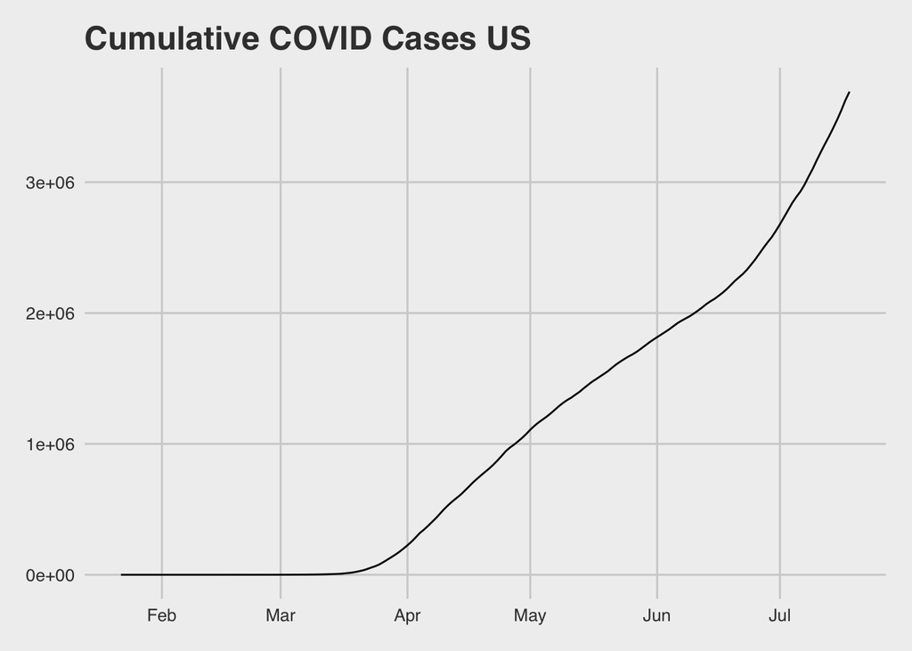

```r
library(ggplot2)
library(ggthemes)

ggplot(data = us, aes(x=date, y=positive))+
  geom_line(color="black")+
  labs(title = "Cumulative COVID Cases US", y = "Millions", x = "") +
  theme_fivethirtyeight()
```

### Cumulative COVID Hospitalized Cases in US

The total hospitilizations due to covid appear to also increase over time. We do see a little more movement in this graph, however, overall clearly increasing.

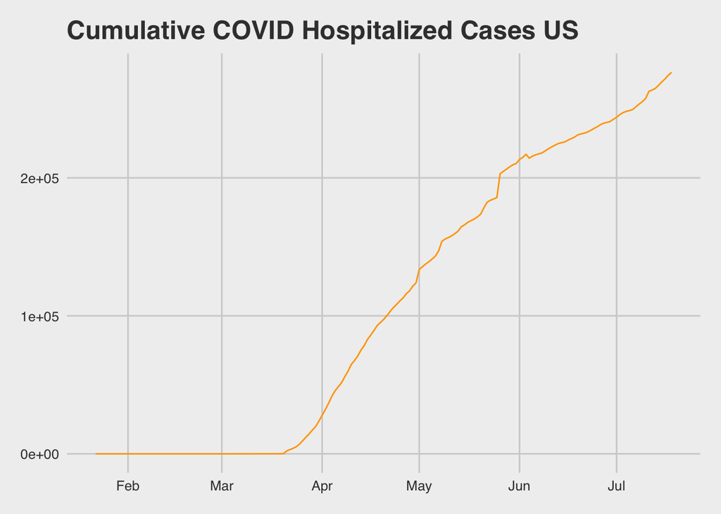

```r
ggplot(data = us, aes(x=date, y=hospitalizedCumulative))+
  geom_line(color="orange")+
  labs(title = "Cumulative COVID Hospitalized Cases US", y = "Millions", x = "") +
  theme_fivethirtyeight()
```

### Cumulative COVID Related Deaths in US

The cumulative deaths are also increasing over time. We can clearly see what appears to be an upward trend.

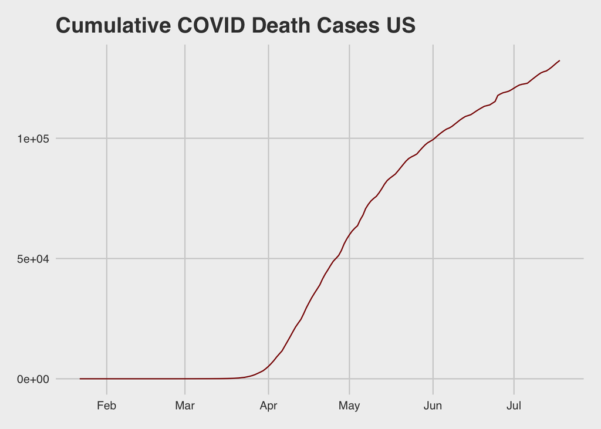

```r
ggplot(data = us, aes(x=date, y=death))+
  geom_line(color="dark red")+
  labs(title = "Cumulative COVID Death Cases US", y = "100 Thousands", x = "") +
  theme_fivethirtyeight()
```

## New and Currently COVID Case Variable Review

In an attempt to look at a more micro view of the COVID data we review some of the new and cumulative variables below. We are looking to surface those variables that will be the most benficial in forecasting the severity of cases and therefore hospital resources moving forward.

### New Confirmed COVID in US

When we start to investigate at a more micro level and review something like the daily new cases we see more trending behavior and something that can be more properly evaluated. Newly confirmed cases have a little more inforamtion to tell use from a trend perspective. We can see some pseudo-cyclic behavior alongside some heavy wandering behavior.

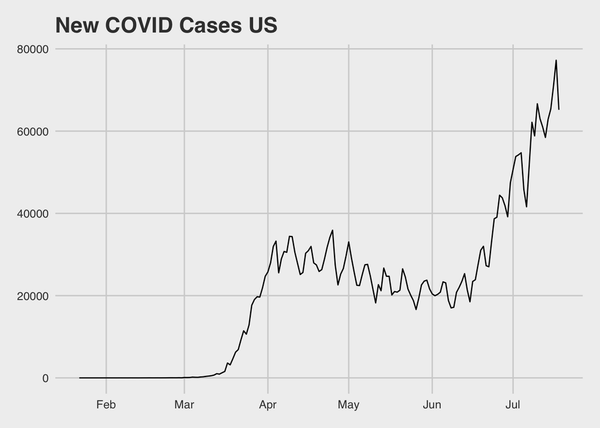

```r
ggplot(data = us, aes(x=date, y=positiveIncrease))+
  geom_line(color="black")+
  labs(title = "New COVID Cases US", y = "Thousands", x = "") +
  theme_fivethirtyeight()
```

### Currently COVID Hospitalizations in US

When measuring the severity of cases, we wanted to make sure that we are including the most severe cases; we believe that a good indicator of this would be a hospitalization metric. This is not only because the severe cases would end up hospitalized, but because of the intial fear of resources and space, it would also be a key forecast for medical communities to be prepared for potential next round of patients.

We have seen that the research suggests ‘that most people who contract the new coronavirus develop mild cases of Covid-19’ from an article released in June that can be found [here](https://www.advisory.com/daily-briefing/2020/06/01/asymptomatic-patients). Due to this fact of likely a-symptomatic patients, hospitalization metrics reveal themselves to be a more accurate representation of severe cases.

Originally we were going to evaluate the new COVID hospitalization cases. However, upon closer review it became clear that large states that were hit the hardest were failling to reporting this metric. We were able to confirm this analysis when we compared the New versus Current metrics and see that there is a large spike in the hospitalization cases overall, but we are not seeing the same results reflected in the New COVID cases metric. Therefore, we err on the side of caution and move forward with modeling our Currently COVID hospitalized metric.

Looking at a more micro view of currently hospitalized COVID cases shows us much more behavior that we might be able to evaluate moving forward. Below we can see what appears to be heavy wandering behavior and if we look closely, some additional noise that could be pseudo-cyclic behavior hidden by the large numbers.

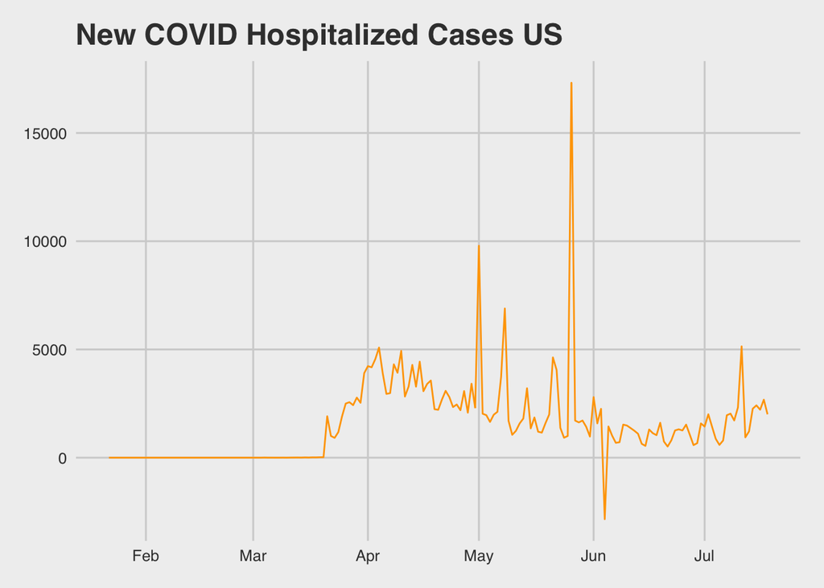

```r
ggplot(data = us, aes(x=date, y=hospitalizedIncrease))+
  geom_line(color="orange")+
  labs(title = "New COVID Hospitalized Cases US", y = "Thousands", x = "") +
  theme_fivethirtyeight()
```

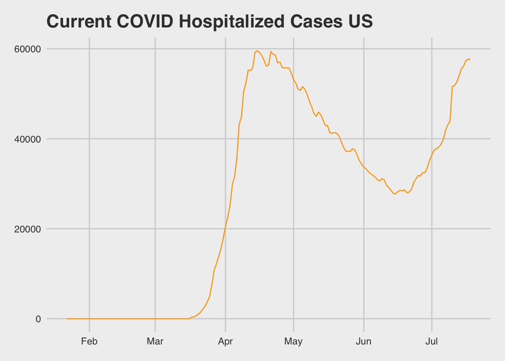

```r
ggplot(data = us, aes(x=date, y=hospitalizedCurrently))+
  geom_line(color="orange")+
  labs(title = "Current COVID Hospitalized Cases US", y = "Thousands", x = "") +
  theme_fivethirtyeight()
```

### New COVID Deaths in US

When we review the new death cumulative count we can see what again appears to be a pseudo-cyclic behavior with maybe some slight wandering tendencies.

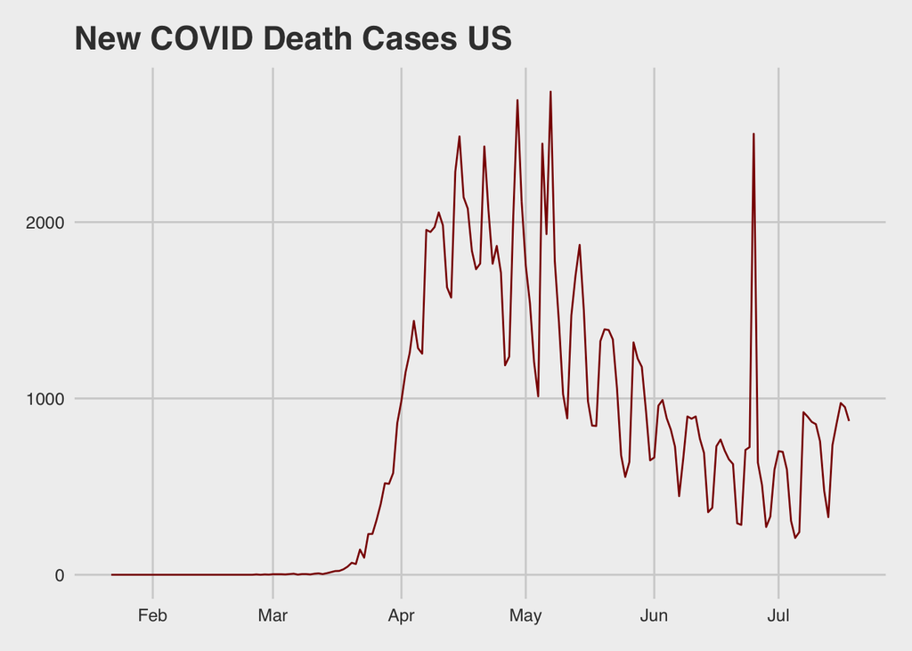

```r
ggplot(data = us, aes(x=date, y=deathIncrease))+
  geom_line(color="dark red")+
  labs(title = "New COVID Death Cases US", y = "Thousands", x = "") +
  theme_fivethirtyeight()
```

## Caculated Variables Creation & Review

### Positive Percent Rate

When reviewing the daily positivty rate, the metric discussed that is more reported on lately. We see the positivity rate actually decreasing over time. We would expect this outcome since we saw a drastic increase in testing over time as well.

While this metric is better than just new cases to forecast severity (it normalizes to number of tests), it doesn’t tell us anything about impact. We tend towards the currently hospitalized metrics because it allows us to take into consideration things such medical resources and why, we as a nation, were attempting to flatten the curve.

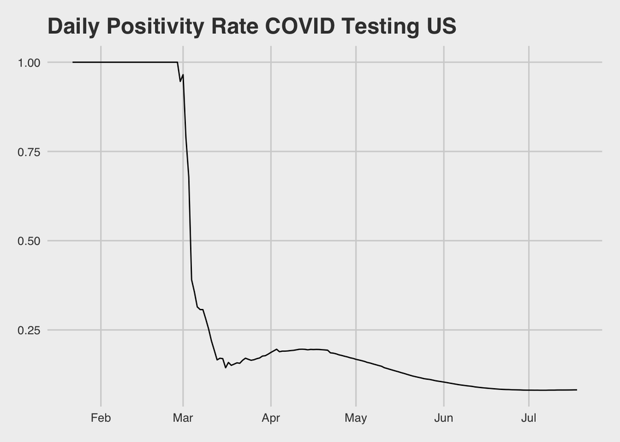

```r
us$posRate <- us$positive / us$totalTestResults

ggplot(data = us, aes(x=date, y=posRate))+
  geom_line(color="black")+
  labs(title = "Daily Positivity Rate COVID Testing US", y = "Rate", x = "") +
  theme_fivethirtyeight()
```

### Hospitalization Rate

While reviewing this data we determined that this was not a best metric to review moving forward for forecasting severity of cases. The reason being is that individuals who were hospitalized for reasons other than COVID but then returned a positive test would be listed as a COVID patient, even if the virus itself was not affecting them (a-symptomatic.) Therefore we tend towards currently hospitalized as our severity metric, since it takes into account all hospitalizatoin resources and doesn’t just try to focus on a metric that appears to be misleading at this time.

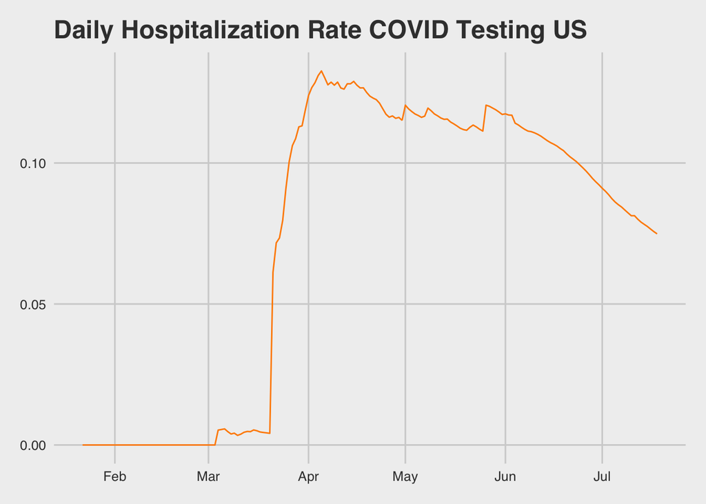

```r
us$hospRate <- us$hospitalizedCumulative / us$positive

ggplot(data = us, aes(x=date, y=hospRate))+
  geom_line(color="dark orange")+
  labs(title = "Daily Hospitalization Rate COVID Testing US", y = "Rate", x = "") +
  theme_fivethirtyeight()
```

### Recovery Rate

In an opposite pattern of the previous rates we have evaluted we actually see a sharp increase in recovyer rate over time. It appears to be plateauing recently, but what we would expect is for it to continue to increase and provide a final percent of infected individuals who have recovered from COVID.

At first we thought the Recovery Rate would be a great opposite indicator to compare against a severity indicator. However, upon closer investigation we quickly realized that merely a few states were even collecting some of the recovered data. Without an actual number coming from all states this would not be a good refelcting of the recovery rate of COVID over all. This data would not be good to forecast.

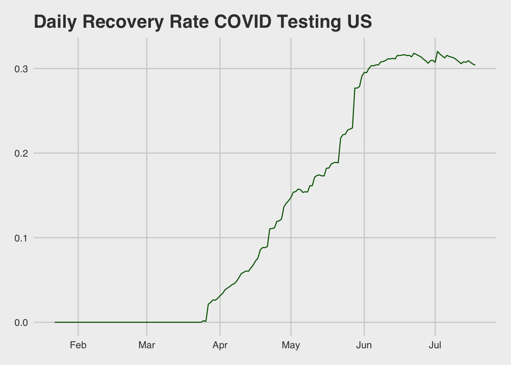

```r
us$recRate <- us$recovered / us$positive

ggplot(data = us, aes(x=date, y=recRate))+
  geom_line(color="dark green")+
  labs(title = "Daily Recovery Rate COVID Testing US", y = "Rate", x = "") +
  theme_fivethirtyeight()
```

### Death Rate

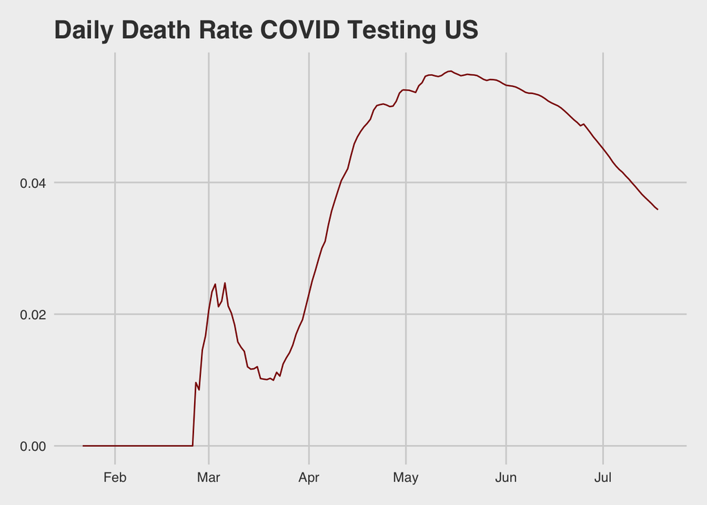

```r
us$deathRate <- us$death / us$positive

ggplot(data = us, aes(x=date, y=deathRate))+
  geom_line(color="dark red")+
  labs(title = "Daily Death Rate COVID Testing US", y = "Rate", x = "") +
  theme_fivethirtyeight()
```

## Matrix Scatterplot of Surfaced Variables

Trying to create pairs plots for all the variables against eachother would be very difficult to interpret. As suspected there are highly correlated variables since we are graphing things like total postive tests and new positive tests. These variables would be inherently correlated to one another because they are communicating similar data. Since this is the case we will only review a scatterplot of those variables we have surfaced above and will use for forecasting the multivariate testing.

```r
library(GGally)
```

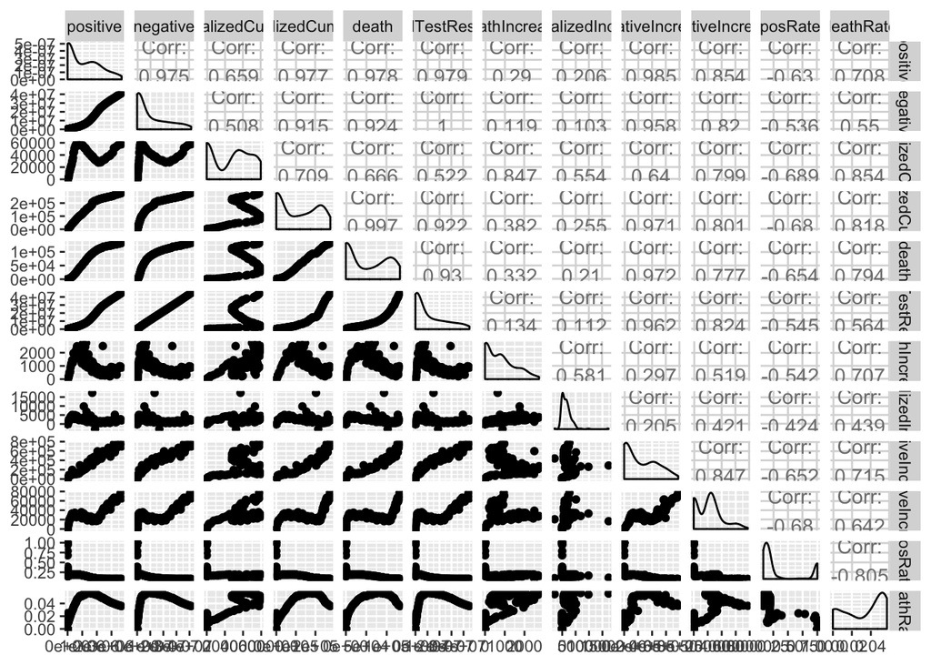

```r
scatter <- subset(us, select = c(positive, negative, hospitalizedCurrently, hospitalizedCumulative, death, totalTestResults, deathIncrease, hospitalizedIncrease, negativeIncrease, positiveIncrease, posRate, deathRate))
ggpairs(scatter)
```